# Bayesian Estimation and Forecasting

Jim Hughes

12 August 2019

## Aim

This document aims to provide a workflow for empirical Bayesian estimation and Bayesian forecasting using the `mrgsolve` package in R. Each step covered is accompanied by an example script. The steps covered by this manuscript are:

- Simulation of “observed data” using `mrgsolve`
- Utilising empirical Bayesian estimation to obtain individual pharmacokinetic parameters
- Utilising Bayesian forecasting for dose optimisation

## Overview

For a given set of observed pharmacokinetic data for which there is an existing population pharmacokinetic model, the individual pharmacokinetic parameters (clearance, CL; volume of distribution, Vd etc.) can be obtained using empirical Bayesian estimation. These individual parameters are also known as empirical Bayesian estimates (EBEs).

Software such as NONMEM provide EBEs as a part of it’s post-hoc analysis. While this is often considered the easiest way to get EBEs, there are cases where the use of NONMEM is not practical, feasible or optimal. Fortunately, EBEs can be obtained using R, by utilising packages such as `mrgsolve`, `RxODE`, `deSolve` and `PKADVAN`.

Bayesian forecasting is a method of extrapolating from observed data to predict future events. With pharmacokinetic data, this is done to predict patient exposure after given certain doses with the aim of optimising that dose to maximise efficacy and minimise toxicity. Bayesian forecasting uses EBEs to make it’s predictions.

### R Packages

The three differential equation solver packages `mrgsolve`, `RxODE` and `deSolve` allow the user to define any model, while `PKADVAN` is limited to the pre-defined model types within the package due to it’s use of analytical solutions. The requirement of an R tools installation for `mrgsolve` and `RxODE` may cause difficulties on some systems, making `deSolve` and `PKADVAN` easier to use with little setup required. While `mrgsolve`, `RxODE` and `PKADVAN` work using similar datasets and workflows to those seen in NONMEM, while `deSolve` is structured somewhat differently making it’s use less intuitive for NONMEM users.

In this document R version 3.4.4 was used with the following packages:

- `mrgsolve` ver. 0.9.1
- `dplyr` ver. 0.8.1
- `tibble` ver. 2.1.1
- `MASS` ver. 7.3.51.4
- `ggplot2` ver. 3.1.1
- `purrr` ver. 0.3.2
- `plyr` ver. 1.8.4

## Observed Data

The observed data used to obtain EBEs will need to be in a long-format (also known as NONMEM-format), as typically used in NONMEM. This data format describes in each row, data that describes the dose and concentrations at each time. For this document, an example dataset will be simulated.

Simulating observed data requires:

- a population pharmacokinetic model
- a description of the population of interest
- a drug regimen describing dose and concentration times

These three components are defined as three separate files in the example files. The `regimen.R` R script reads in both the model and population before simulating concentrations according to the defined regimen.

### Population Pharmacokinetic Model

Population pharmacokinetic models defined for use with `mrgsolve` are layed out in a fashion similar to NONMEM. Information on `mrgsolve` model definition can be found in the user guide found at https://mrgsolve.github.io/user_guide/.

The following model is a vancomycin population pharmacokinetic model by Goti et al. (reference below), which uses infusion times that are dependent on patient dose as specified by the Clinical Practice Guideline for vancomycin dosing that is used by SA Health hospitals. This can be found at: https://www.sahealth.sa.gov.au/wps/wcm/connect/public+content/sa+health+internet/resources/policies/dosing+and+monitoring+of+vancomycin+in+adults+-+clinical+practice+guideline

> Goti V, Chaturvedula A, Fossler MJ, Mok S, Jacob JT. Hospitalized Patients With and Without Hemodialysis Have Markedly Different Vancomycin Pharmacokinetics: A Population Pharmacokinetic Model-Based Analysis. Ther Drug Monit. 2018;40(2):212-221.

In the model definition of the population parameter variability (ETA samples from the OMEGA distribution) are defined externally. This is required for empirical Bayesian estimation.

```r
# Vancomycin Population Pharmacokinetic Model - Goti et al.
# ------------------------------------------------------------------------------
# Load libraries
  library(dplyr)
  library(mrgsolve)
```

```r
# Define model code
  code <- '
$INIT  // Initial Conditions for Compartments
  CENT = 0,  // Central compartment
  PERI = 0,  // Peripheral compartment
  AUC = 0,  // Area under the curve

$SET  // Set Differential Equation Solver Options
  atol = 1e-8, rtol = 1e-8
  maxsteps = 100000

$PARAM  // Population parameters
  TVCL = 4.5,  // clearance (L/h)
  TVVC = 58.4,  // central volume of distribution (L)
  TVVP = 38.4,  // peripheral volume of distribution (L)
  TVQ = 6.5,  // inter-compartmental clearance (L/h)

  AVBWT = 70,  // average body weight (kg)
  AVCRCL = 120,  // average creatinine clearance (mL/min)

  // Covariate Effects
  CL_CRCL = 0.8,  // creatinine clearance on clearance
  CL_DIAL = 0.7,  // haemodialysis on clearance
  VC_DIAL = 0.5,  // haemodialysis on volume of distribution

  // Residual Variability
  ERR_PRO = 0.227,  // proportional error (fraction)
  ERR_ADD = 3.4,  // additive error (mg/L)

  // Default Covariate Values for Simulation
  WT = 79,  // body weight (kg)
  CRCL = 62,  // creatinine clearance (mL/min)
  DIAL = 0,  // haemodialysis status (0 - not on dialysis; 1 - on dialysis)

  // Default ETA Values for Simulation
  // Allocated in population so set to zero
  ETA1 = 0,  // PPVCL
  ETA2 = 0,  // PPVVC
  ETA3 = 0,  // PPVVP

  // Default EPS values for simulation
  // Allocated in population so set to zero
  EPS1 = 0,  // RUVPRO
  EPS2 = 0,  // RUVADD

$OMEGA  // Population parameter Variability
  name = "omega1"
  block = FALSE
  0.158404  // PPVCL
  0.665856  // PPVVC
  0.326041  // PPVVP

$SIGMA  // Residual Unexplained Variability
  block = FALSE
  1  // RUVPRO
  1  // RUVADD

$PREAMBLE  // Set up C++ Environment to Capture Last Dose
  double last_dose = 0;

$MAIN  // Covariate Effects
  double COVCL = TVCL*pow(CRCL/120, CL_CRCL)*pow(CL_DIAL, DIAL);
  double COVVC = TVVC*pow(WT/70, 1)*pow(VC_DIAL, DIAL);

  // Individual Parameter Values
  double CL = COVCL*exp(ETA1);  // *exp(ETA(1))
  double VC = COVVC*exp(ETA2);  // *exp(ETA(2))
  double VP = TVVP*exp(ETA3);  // *exp(ETA(3))
  double Q = TVQ;

  // Infusion Duration (hours)
  if(EVID == 1) last_dose = self.amt;  // capture latest dose
  if(ceil(last_dose/1000) <= 1) {  // if dosage is less than or equal to 1g
    D_CENT = 60/60;  // set infusion time to 60 minutes
  } else if(ceil(last_dose/1500) <= 1) {  // if dosage less than or equal to 1.5g
    D_CENT = 90/60;  // set infusion time to 90 minutes
  } else if(ceil(last_dose/2000) <= 1) {  // if dosage less than or equal to 2g
    D_CENT = 120/60;  // set infusion time to 120 minutes
  } else {  // if infusion time more than 2g
    D_CENT = self.amt/1000;  // set infusion time to 1g/hour
  }

$ODE  // Differential Equations
  double C1 = CENT/VC;
  double C2 = PERI/VP;

  dxdt_CENT = C2*Q - C1*Q - C1*CL;
  dxdt_PERI = C1*Q - C2*Q;
  dxdt_AUC = C1;

$TABLE  // Determines Values and Includes in Output
  double IPRE = C1;  // individual prediction
  double DV = IPRE*(1 + EPS1*ERR_PRO) + EPS2*ERR_ADD;  // observed concentration
  // double DV = IPRE*(1 + EPS(1)*ERR_PRO) + EPS(2)*ERR_ADD;  // debug

$CAPTURE
  WT CRCL DIAL IPRE DV C2 CENT PERI AUC
  CL VC VP Q COVCL COVVC
  ETA1 ETA2 ETA3 EPS1 EPS2
'

# - - - - - - - - - - - - - - - - - - - - - - - - - - - - - - - - - - - - - - -
# Compile the model code
  mod <- mrgsolve::mcode("vancPK", code)
```

```
## Building vancPK ...
```

```
## done.
```

This code can be found in the `model.R` script.

### Population of Interest

Given that the population pharmacokinetic model includes weight, creatinine clearance and dialysis status as covariates, these are what should be specified when defining the population of interest. If using observed data, then these are the demographic data that need to be extracted from the available data.

While covariates can be sampled from random distributions, here the population of interest is simple. All patients are defined as having an average weight and not being on haemodialysis. Patients are assigned one of four values for creatinine clearance.

```r
# Vancomycin PopPK Model Simulation - Population
# ------------------------------------------------------------------------------
# Create population of representative patients for simulations
# - - - - - - - - - - - - - - - - - - - - - - - - - - - - - - - - - - - - - - -
# Define demographic data
# Number of individuals
  nid <- 4*10  # Number of individuals
  ID <- 1:nid  # Sequence of individual ID's

# Set seed used for random number generation (important for consistent results)
  set.seed(123456)

# Reference population
# Weight - 79 kg (?) [33 - 255]
# Creatinine Clearance - 62 (?) [4 - 150]
# Haemodialysis - 18.5% on dialysis

# Simulated population
# Weight - 75 kg (fixed)
# Creatinine Clearance - 100, 75, 50, 25 ml/min (four fixed groups)
# Haemodialysis - 0% (all not on dialysis)
  cov_tb <- tibble::tibble(
    WT = rep(75, times = nid),
    CRCL = rep(c(100, 75, 50, 25), each = nid/4),
    DIAL = rep(0, times = nid)
  )
```

The population also requires a description of the population parameter variability. This is done by extracting the description of variability from the model and then using it to obtain random samples from a normal distribution. The code below is designed to work for any combination of OMEGA blocks (with and without correlation between parameter variability).

Covariate and variability data are bound together into the resulting population dataset. This is in a subject-level format (one patient per line).

```r
# Population parameter variability
# - - - - - - - - - - - - - - - - - - - - - - - - - - - - - - - - - - - - - - -
# Extract omega block values from model and allocate individual distributions
  eta_tb <- mrgsolve::omat(mod, make = TRUE) %>%
    {MASS::mvrnorm(n = nid, mu = rep(0, dim(.)[1]), Sigma = .)} %>%
    tibble::as_tibble() %>%
    dplyr::rename_all(function(x) paste0("ETA", readr::parse_number(x)))

# Create data frame of individuals with varying demographics and ETA values
  pop_tb <- dplyr::bind_cols(ID = ID, cov_tb, eta_tb)
```

All of this code can be found in the `population.R` script.

### Drug Regimen

The drug regimen defines when doses are given to patients, in addition to times at which concentration predictions are desired (or are available with observed data). For a dosing simulation study, this is often referred to as the induction regimen as it is the part that is consistent between different dosing strategies.

Below shows the induction regiment for the vancomycin simulation study. Concentration times are relatively dense for plotting, and then later filtered to better represent blood sample times.

```r
# Vancomycin PopPK Model Simulation - Induction Regimen
# ------------------------------------------------------------------------------
# Create simulation input dataset
# Define time points
  conc_times <- seq(from = 0, 24*7, by = 0.25)  # 1 day of half hourly data
  freq_bd <- 12*0:14
  freq_d <- c(0, 24*0:6 + 12)
  amt_load <- 2000  # loading dose (mg)
  amt_mnt1 <- 1500  # maintenence dose CrCL = 100 mL/min (mg)
  amt_mnt2 <- 1000  # maintenence dose CrCL = 75 mL/min (mg)
  amt_mnt3 <- 750  # maintenence dose CrCL = 50 mL/min (mg)
  amt_mnt4 <- 1000  # maintenence dose CrCL = 25 mL/min (mg)

# Create concentration dataset
  pk_tb <- tibble::tibble(
    ID = rep(ID, each = length(conc_times)),
    time = rep(conc_times, times = nid),
    amt = 0,
    cmt = 1,
    evid = 0,
    rate = 0
  )

# Incorporate maintenance dose at dose times
  dose_cols <- c("amt", "evid", "rate")
  sub_mnt1 <- with(pk_tb, ID %in% 1:(nid/4) & time %in% freq_bd)
  pk_tb[sub_mnt1, dose_cols] <- data.frame(amt = amt_mnt1, evid = 1, rate = -2)

  sub_mnt2 <- with(pk_tb, ID %in% (nid/4+1):(nid*2/4) & time %in% freq_bd)
  pk_tb[sub_mnt2, dose_cols] <- data.frame(amt = amt_mnt2, evid = 1, rate = -2)

  sub_mnt3 <- with(pk_tb, ID %in% (nid*2/4+1):(nid*3/4) & time %in% freq_bd)
  pk_tb[sub_mnt3, dose_cols] <- data.frame(amt = amt_mnt3, evid = 1, rate = -2)

  sub_mnt4 <- with(pk_tb, ID %in% (nid*3/4+1):nid & time %in% freq_d)
  pk_tb[sub_mnt4, dose_cols] <- data.frame(amt = amt_mnt4, evid = 1, rate = -2)

# Define first dose as loading dose
  pk_tb[pk_tb$time == 0, "amt"] <- amt_load  # loading dose
```

Much like in the population where the population variability was defined external from the model simulation, the observation variability (residual unexplained variability/EPS samples from SIGMA distribution) should also be defined externally if using Bayesian forecasting.

As can be seen, it uses very similar code to that used for population variability. The main difference is that random samples are taken from a normal distribution for each observation, rather than each subject.

```r
# Residual unexplained variability
# - - - - - - - - - - - - - - - - - - - - - - - - - - - - - - - - - - - - - - -
# Create residual unexplained variability dataset
  input_dim <- nid*length(conc_times)
  eps_tb <- mrgsolve::smat(mod, make = TRUE) %>%  # Omega matrix from model
    {MASS::mvrnorm(n = input_dim, mu = rep(0, dim(.)[1]), Sigma = .)} %>%
    tibble::as_tibble() %>%  # matrix used to sample from normal distribution
    dplyr::rename_all(function(x) paste0("EPS", readr::parse_number(x)))

# Combine to make final input dataset
  input_tb <- dplyr::bind_cols(pk_tb, eps_tb)
```

The model is then simulated using the code below. The population pharmacokinetic model is “piped” into each line. Effectively this provides instructions to the model: `data_set`, simulate this regimen; `idata_set`, with this population; `carry_out`, provide these columns as additional output.

```r
# Simulate standard dosing regimen
# - - - - - - - - - - - - - - - - - - - - - - - - - - - - - - - - - - - - - - -
# Pipe dataset to model
  output_tb <- mod %>%
    mrgsolve::data_set(input_tb) %>%  # set input data (observations/events)
    mrgsolve::idata_set(pop_tb) %>%  # set individual data (sets ETAs)
    mrgsolve::carry_out(amt, evid, rate, cmt) %>%  # copy to simulated output
    mrgsolve::mrgsim() %>%  # simulate using mrgsolve
    tibble::as_tibble()
```

Using this dataset, Bayesian estimation and forecasting will be demonstrated. Here is an example of the model output.

```
## # A tibble: 6 x 26
##      ID  time  evid   amt   cmt  rate  CENT  PERI   AUC    WT  CRCL  DIAL
##   <dbl> <dbl> <dbl> <dbl> <dbl> <dbl> <dbl> <dbl> <dbl> <dbl> <dbl> <dbl>
## 1     1  0        1  2000     1    -2    0   0    0        75   100     0
## 2     1  0.25     0     0     1     0  247.  1.59 0.251    75   100     0
## 3     1  0.5      0     0     1     0  488.  6.14 0.995    75   100     0
## 4     1  0.75     0     0     1     0  723. 13.4  2.22     75   100     0
## 5     1  1        0     0     1     0  953. 23.0  3.92     75   100     0
## 6     1  1.25     0     0     1     0 1178. 34.8  6.07     75   100     0
## # ... with 14 more variables: IPRE <dbl>, DV <dbl>, C2 <dbl>, CL <dbl>,
## #   VC <dbl>, VP <dbl>, Q <dbl>, COVCL <dbl>, COVVC <dbl>, ETA1 <dbl>,
## #   ETA2 <dbl>, ETA3 <dbl>, EPS1 <dbl>, EPS2 <dbl>
```

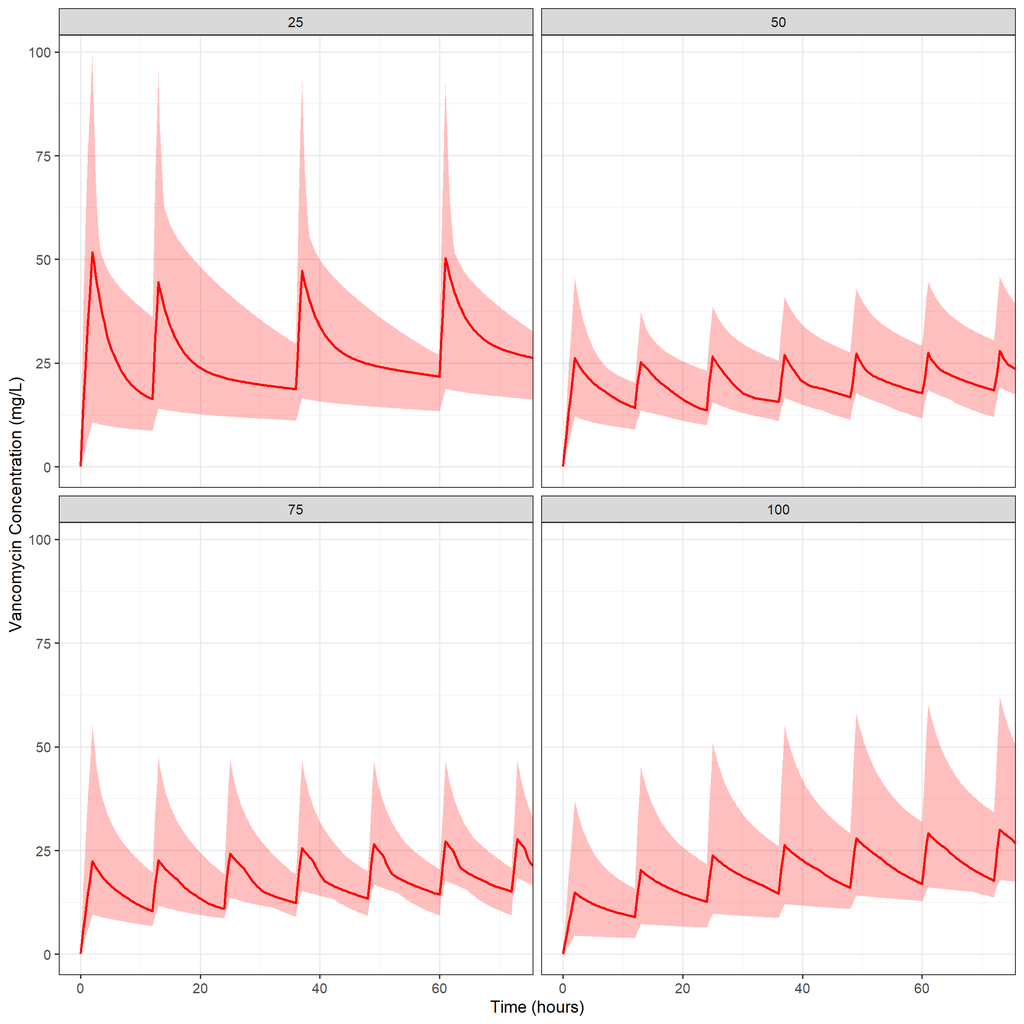

This will typically be subset according to the blood samples that would be taken. As an example, blood samples may be taken just prior to dosing. Therefore using concentration predictions at dose times would be appropriate.

If doing a simulation study, it’s important keep the original ETA and EPS values as they are required for the simulations that occur between each round of dose optimisation. But there is also a requirement of being careful with these values, as these values are not known during use of Bayesian estimation or forecasting in practice.

```
## # A tibble: 6 x 12
##      ID  time   amt  evid  rate   cmt    WT  CRCL  DIAL    DV    EPS1
##   <dbl> <dbl> <dbl> <dbl> <dbl> <dbl> <dbl> <dbl> <dbl> <dbl>   <dbl>
## 1     1     0  2000     1    -2     1    75   100     0  4.02  0.802
## 2     1    12  1500     1    -2     1    75   100     0  2.83  0.138
## 3     1    24  1500     1    -2     1    75   100     0 12.7  -0.0635
## 4     1    36  1500     1    -2     1    75   100     0  9.48  0.720
## 5     1    48  1500     1    -2     1    75   100     0 20.1   0.421
## 6     1    60  1500     1    -2     1    75   100     0 15.2   1.83
## # ... with 1 more variable: EPS2 <dbl>
```

All of this code can be found in the `regimen.R` script.

## Empirical Bayesian Estimation

Empirical Bayesian estimation (also known as *maximum a priori* estimation), determines individual pharmacokinetic parameters by minimising a maximum likelihood objective function. Sampled blood concentrations along with dose and covariate information is used (from observed or simulated data) along with a population pharmacokinetic model for estimation.

Estimation is undertaken by an optimisation algorithm (R base function `optim`). This minimises an objective function value as defined below. This provides estimates that maximise the two following properties:

- the likelihood that the difference between the observed concentration data and the individual concentration predictions is described by the residual unexplained variability distribution of the model (posterior likelihood)
- the likelihood that parameter estimates are sampled from the population parameter variability distribution as described by the model (prior likelihood)

$$OFV = -ln \left( \sum_{i=1}^n \frac{
e^{ -\frac{
( C_{trough,i} - \hat{C}_{trough,i} )^2
}{
2( \hat{C}_{trough,i} \sigma )^2
}}
}{
\sqrt{2\pi ( \hat{C}_{trough,i} \sigma )^2}
} + \sum_{k=1}^s \frac{
e^{ -\frac{ \eta_k^2 }{ 2 \omega_k^2 }}
}{
\sqrt{2 \pi \omega_k^2}
} \right)$$

### Single Patient Estimation

As an example, the EBEs for a single patient are estimated in this section. The data available for this single patient is shown below.

```r
  single_tb <- output_tb %>%
    dplyr::filter(evid == 1 & ID == 1 & time <= 72) %>%
    dplyr::select(ID, time, amt, evid, rate, cmt, WT, CRCL, DIAL, DV)
  single_tb
```

```
## # A tibble: 7 x 10
##      ID  time   amt  evid  rate   cmt    WT  CRCL  DIAL    DV
##   <dbl> <dbl> <dbl> <dbl> <dbl> <dbl> <dbl> <dbl> <dbl> <dbl>
## 1     1     0  2000     1    -2     1    75   100     0  4.02
## 2     1    12  1500     1    -2     1    75   100     0  2.83
## 3     1    24  1500     1    -2     1    75   100     0 12.7
## 4     1    36  1500     1    -2     1    75   100     0  9.48
## 5     1    48  1500     1    -2     1    75   100     0 20.1
## 6     1    60  1500     1    -2     1    75   100     0 15.2
## 7     1    72  1500     1    -2     1    75   100     0 22.1
```

First the predicted concentration that corresponds with the provided ETA values is determined.

```r
# Define bayesian estimation function
  # bayes_estimate_fn <- function(par) {
  # Debug:
    par <- c(0.998, 0.999, 1.002)
    ETABSV <- mrgsolve::omat(mod, make = TRUE) %>% diag()
    prev_DV <- single_tb %>%
      dplyr::pull(DV)
  # Describe parameters to be optimised within mrgsolve data set
  # Parameters are defined as `exp(ETA)`, log transform to get ETA value
    ETA <- log(par)
  # The ETAs are then defined as a single row data.frame with ID for use later
    ETA_df <- as.data.frame(matrix(
      c(unique(single_tb$ID), ETA),
      nrow = 1
    ))
    names(ETA_df) <- c("ID", paste0("ETA", 1:length(ETA)))
  # Determine predictions that correspond with these ETA values
  # Define mrgsolve dataset
    estim_tb <- single_tb %>%
  # Remove DV column, not needed for simulation
      dplyr::select(-DV) %>%
  # Merge in ETA data.frame using ID
      inner_join(ETA_df, by = "ID") %>%  # merge in ETA data
      tibble::glimpse(width = 50) %>%
  # Run data through mrgsolve, idata_set is not used, as population data is
  # included in the longitudinal dataset
  # The `.` in the data_set function tells the pipe to put the data in this
  # argument, rather than being the value of the first argument.
      mrgsolve::data_set(x = mod, data = .) %>%
      mrgsolve::carry_out(amt, evid, rate, cmt) %>%
      mrgsolve::mrgsim() %>%
      tibble::as_tibble() %>%
  # Ensure IPRED has finite values
  # This uses an if else statement to check if IPRE is not finite
  # If IPRE being not finite is true, make it a very small number
  # Otherwise IPRE can stay the same
      dplyr::mutate(IPRE = dplyr::if_else(
        condition = !is.finite(IPRE) | IPRE < .Machine$double.eps,
        true = .Machine$double.eps,
        false = IPRE
      ))
```

```
## Observations: 7
## Variables: 12
## $ ID   <dbl> 1, 1, 1, 1, 1, 1, 1
## $ time <dbl> 0, 12, 24, 36, 48, 60, 72
## $ amt  <dbl> 2000, 1500, 1500, 1500, 1500, 15...
## $ evid <dbl> 1, 1, 1, 1, 1, 1, 1
## $ rate <dbl> -2, -2, -2, -2, -2, -2, -2
## $ cmt  <dbl> 1, 1, 1, 1, 1, 1, 1
## $ WT   <dbl> 75, 75, 75, 75, 75, 75, 75
## $ CRCL <dbl> 100, 100, 100, 100, 100, 100, 100
## $ DIAL <dbl> 0, 0, 0, 0, 0, 0, 0
## $ ETA1 <dbl> -0.002002003, -0.002002003, -0.0...
## $ ETA2 <dbl> -0.0010005, -0.0010005, -0.00100...
## $ ETA3 <dbl> 0.001998003, 0.001998003, 0.0019...
```

```r
  # The output shows the structure of the data before simulation occurs
  # The output below shows the structure of the simulated data
    estim_tb
```

```
## # A tibble: 32 x 26
##       ID  time  evid   amt   cmt  rate  CENT  PERI    AUC    WT  CRCL  DIAL
##    <dbl> <dbl> <dbl> <dbl> <dbl> <dbl> <dbl> <dbl>  <dbl> <dbl> <dbl> <dbl>
##  1     1     0     0     0     0     0    0    0     0       75   100     0
##  2     1     0     1  2000     1    -2    0    0     0       75   100     0
##  3     1     1     0     0     0     0  924.  46.6   7.58    75   100     0
##  4     1     2     0     0     0     0 1720. 168.   28.9     75   100     0
##  5     1     3     0     0     0     0 1494. 295.   54.5     75   100     0
##  6     1     4     0     0     0     0 1318. 383.   76.9     75   100     0
##  7     1     5     0     0     0     0 1181. 442.   96.9     75   100     0
##  8     1     6     0     0     0     0 1073. 481.  115.      75   100     0
##  9     1     7     0     0     0     0  986. 505.  131.      75   100     0
## 10     1     8     0     0     0     0  914. 517.  147.      75   100     0
## # ... with 22 more rows, and 14 more variables: IPRE <dbl>, DV <dbl>,
## #   C2 <dbl>, CL <dbl>, VC <dbl>, VP <dbl>, Q <dbl>, COVCL <dbl>,
## #   COVVC <dbl>, ETA1 <dbl>, ETA2 <dbl>, ETA3 <dbl>, EPS1 <dbl>,
## #   EPS2 <dbl>
```

```r
  # As can be seen, `mrgsolve` has default simulation times, so it is important
  # that only the values for IPRED that correspond with the DV values that are
  # available. The IPRED values are referred to as `yhat` as they are
  # predictions of `y` (DV).
  # Define yhat
    sample_times <- dplyr::pull(single_tb, time)
    yhat <- dplyr::filter(estim_tb, evid == 1 & time %in% sample_times) %>%
      dplyr::pull(IPRE)
    length(yhat) == length(prev_DV)
```

```
## [1] TRUE
```

Now the that predicted concentrations that correspond with the provided ETA values has been determined, the objective function value can be determined. As shown above this has two parts. The first part, the posterior, requires:

- observed concentration data
- predicted concentration data (no RUV)
- standard deviation for each observation

The standard deviation is determined from the description of RUV from the popPK model. The value given for standard deviation is equivalent to what would be defined as the weight or `W` in some styles of NONMEM model definition. How this value is determined depends on the RUV model type:

- If the model has additive error, then this value will be the same for each value as the error does not change between observations
  - NONMEM: `DV = IPRED + ERR_ADD*EPS(1)`
  - NONMEM: `W = ERR_ADD; DV = IPRE + W*EPS(1)`
  - R: `loglikpost_sd <- mod$ERR_ADD`
- If the model has proportional error, then this value will be dependent on the value of `yhat`
  - NONMEM: `DV = IPRED*(1 + ERR_PRO*EPS(1))`
  - NONMEM: `W = IPRED*ERR_PRO; DV = IPRE + W*EPS(1)`
  - R: `loglikpost_sd <- yhat*mod$ERR_PRO`
- If the model has additive and proportional error, then this value will be dependent on the value of `yhat` but also needs to incorporate the additve error
  - NONMEM: `IPRED*(1 + ERR_PRO*EPS(1)) + ERR_ADD*EPS(2)`
  - NONMEM: `W = SQRT((IPRED*ERR_PRO)**2 + ERR_ADD**2); DV = IPRE + W*EPS(1)`
  - R: `loglikpost_sd <- sqrt((yhat*mod$ERR_PRO)^2 + mod$ERR_ADD^2)`

The vancomycin model has additive and proportional error, so the weight is calculated accordingly.

In this case the log-likelihood function `dnorm(..., log = T)` determines the likelihood (given as a log value) that the observed data `prev_DV` was sampled from a normal distribution with a mean equal to the predicted concentration `yhat` and standard deviation equal to the weight for that prediction given by the model `loglikpost_sd`.

```r
  # Posterior log-likelihood
  # Error model: IPRE*(1 + ERR_PRO) + ERR_ADD
  # Can be simplified to: IPRE + W*ERR
  # Where W = sqrt(pow(IPRE*ERR_PRO, 2) + pow(ERR_ADD, 2))
    loglikpost_sd <- sqrt((yhat*mod$ERR_PRO)^2 + mod$ERR_ADD^2)
    loglikpost <- dnorm(prev_DV, mean = yhat, sd = loglikpost_sd, log = T)
    loglikpost
```

```
## [1] -2.843353 -4.456776 -2.709849 -4.022451 -2.671184 -3.305136 -2.735870
```

The second part of the objective function value is the prior log-likelihood. In this case the log-likelihood function determines the likelihood (given as a log value) that the given estimate of ETA `log(par)` was sampled from a normal distribution with a mean equal to zero and standard deviation equatl to the square root of the population parameter variability as defined by the model `ETABSV`.

The sum of the two parts are found, and the negative of the value is found. This is because we want to maximise the likelihood, but the optimisation algorithm is designed to minimise a value. By making the objective function value the inverse of the likelihood, we minimise the objective function value while maximising the likelihood.

```r
  # Prior log-likelihood
    loglikprior <- dnorm(ETA, mean = 0, sd = sqrt(ETABSV), log = T)
    loglikprior
```

```
## [1]  0.002352089 -0.715598361 -0.358578586
```

```r
  # Return objective function value to be minimised
    -1*sum(loglikpost, loglikprior)
```

```
## [1] 23.81644
```

```r
  # }  # end bayes_estimate_fn
```

These processes make up the function that will be used with the optimisation algorithm function `optim()`.

```r
  bayes_estimate_fn <- function(par) {
  # Describe parameters to be optimised within mrgsolve data set
    ETA <- log(par)
    ETA_df <- as.data.frame(matrix(
      c(unique(single_tb$ID), ETA),
      nrow = 1
    ))
    names(ETA_df) <- c("ID", paste0("ETA", 1:length(ETA)))
  # Define mrgsolve dataset
    estim_tb <- single_tb %>%
      dplyr::select(-DV) %>%
    # Define ETAs as estimated
      inner_join(ETA_df, by = "ID") %>%  # merge in ETA data
    # Run data through mrgsolve, with idata using initial tumour size
      mrgsolve::data_set(x = mod, data = .) %>%
      mrgsolve::carry_out(amt, evid, rate, cmt) %>%
      mrgsolve::mrgsim() %>%
      tibble::as_tibble() %>%
    # Ensure IPRED has finite values
      dplyr::mutate(IPRE = dplyr::if_else(
        !is.finite(IPRE) | IPRE < .Machine$double.eps,
        .Machine$double.eps,
        IPRE
      ))
  # Define yhat
    sample_times <- dplyr::pull(single_tb, time)
    yhat <- dplyr::filter(estim_tb, evid == 1 & time %in% sample_times) %>%
      dplyr::pull(IPRE)
  # Posterior log-likelihood
  # Error model: IPRE*(1 + ERR_PRO) + ERR_ADD
  # Can be simplified to: IPRE + W*ERR
  # Where W = sqrt(pow(IPRE*ERR_PRO, 2) + pow(ERR_ADD, 2))
    loglikpost_sd <- sqrt((yhat*mod$ERR_PRO)^2 + mod$ERR_ADD^2)
    loglikpost <- dnorm(prev_DV, mean = yhat, sd = loglikpost_sd, log = T)
  # Prior log-likelihood
    loglikprior <- dnorm(ETA, mean = 0, sd = sqrt(ETABSV), log = T)
  # Return objective function value to be minimised
    return(-1*sum(loglikpost, loglikprior))
  }  # end bayes_estimate_fn
```

When using the `optim` function, the following arguments are used:

- `par` - initial parameters to be optimised: `init_par`
- `fn` - function to be minimised: `bayes_estimate_fn`
- `method` - function that minimises `fn`: `"L-BFGS-B"`
  - there are a large number of methods available, L-BFGS-B is used here as it is well suited to the given problem, and allows the use of upper and lower boundaries for parameters
- `lower` & `upper` - bounds on parameter values: `0.001 - 1000`
  - must provide `lower` and `upper` bounds for each parameter value, in this case we use the same bound for each parameter
- `control` - a list of control parameters
  - `parscale` & `fnscale` - scaling for parameter or function values `par/parscale` `fn(par)/fnscale`, the initial values are used so that the relative parameter and relative objective function value is calculated
  - `factr` & `pgtol` - change the tolerance for convergence

```r
# Define initial parameters
  init_par <- exp(double(length(ETABSV)))
  init_par
```

```
## [1] 1 1 1
```

```r
# Run bayes_estimate_fn using optim()
  bayes_estimate <- optim(init_par, bayes_estimate_fn, method = "L-BFGS-B",
    lower = rep(0.001, times = length(ETABSV)),
    upper = rep(1000, times = length(ETABSV)),
    control = list(
      parscale = init_par, fnscale = abs(bayes_estimate_fn(init_par)),
      factr = 1e12, pgtol = 1e-8
    )
  )
  bayes_estimate
```

```
## $par
## [1] 1.140104 2.769775 1.131680
##
## $value
## [1] 21.38122
##
## $counts
## function gradient
##       15       15
##
## $convergence
## [1] 0
##
## $message
## [1] "CONVERGENCE: REL_REDUCTION_OF_F <= FACTR*EPSMCH"
```

The output shows:

- `$par` - the final parameter estimates
- `$value` - the final value of the objective function value
- `$counts` - number of times the function and gradient function were computed
- `$convergence` - convergence status (0 is successful)
- `$message` - character string providing additional info from the optimiser

When using the `"L-BFGS-B" method the convergence message that you want is`“CONVERGENCE: REL_REDUCTION_OF_F <= FACTR*EPSMCH“`. Any other message can mean that something was not quite right with that optimisation.

### Multiple Patient Estimation

The advantage of using a programming language like R is that we can run the same process for multiple different cases, without writing the same thing for each specific patient. When applying a general function to multiple different patients it is important to ensure that the function works correctly for all patients. Rather than specifically going through each patient, it can be beneficial to set up the function in a way that checks it for you.

This section will go through a Bayes function that is run on multiple patients. It should be noted that the additional components have been added to the process to be run for each patient.

- Section 1: Prepare function environment
- Section 2: Same as single patient, but:
  - now wrapped in a repeat function, designed to repeat the process with different initial parameters if optimisation is unsuccessful
  - sucess of optimisation is determined by whether the `optim` output `$message` shows that convergence was successful
  - now runs `optim` inside a `try` function, therefore if there is an error which would cause R to completely stop and lose all output, instead a new set of initial parameters can be trialled, could also be used for debug purposes
  - counts the number of repeated runs `run_num`, so that initial parameters are changed, could also be used for debug purposes
- Section 3: Simulate concentrations using optimised EBEs

```r
  ebe_fn <- function(bayesin_tb) {
  # - - - - - - - - - - - - - - - - - - - - - - - - - - - - - - - - - - - - -
  #### SECTION 1 ####
  # - - - - - - - - - - - - - - - - - - - - - - - - - - - - - - - - - - - - -
  # Debug:
    # bayesin_tb <- dplyr::filter(output_tb, ID == 1) %>% dplyr::rename(ID2 = ID)
  # Change ID2 column name to ID and determine final time
    # bayesin_tb <- dplyr::rename(bayesin_tb, ID = ID2)  # remove if using ddply
  # Determine sample time and sample concentration
    sample_time <- dplyr::filter(bayesin_tb, evid != 0) %>%
      dplyr::pull(time)
  # - - - - - - - - - - - - - - - - - - - - - - - - - - - - - - - - - - - - -
  #### SECTION 2 ####
  # - - - - - - - - - - - - - - - - - - - - - - - - - - - - - - - - - - - - -
  # Empirical Bayesian Estimation
  # Loop until successful minimisation
    run_num <- 0
    repeat {
    # Initial estimates for Bayes parameters
      ETABSV <- mrgsolve::omat(mod, make = TRUE) %>% diag()
      n_eta <- length(ETABSV)
      init_par <- exp(double(n_eta))
      if (run_num > 0) {
        init_par <- init_par*exp(runif(n_eta, min = -0.01, max = 0.01))
      }
    # Previous dependent variable values
      prev_DV <- dplyr::filter(bayesin_tb, time %in% sample_time) %>%
        dplyr::pull(DV)
    # Define bayesian estimation function
      bayes_estimate_fn <- function(par) {
      # Describe parameters to be optimised within mrgsolve data set
        ETA <- log(par)
        ETA_df <- as.data.frame(matrix(
          c(unique(bayesin_tb$ID), ETA),
          nrow = 1
        ))
        names(ETA_df) <- c("ID", paste0("ETA", 1:length(ETA)))
      # Define mrgsolve dataset
        estim_tb <- bayesin_tb %>%
          dplyr::select(ID, time, evid, amt, cmt, rate, WT, DIAL, CRCL) %>%
      # Define ETAs as estimated
          inner_join(ETA_df, by = "ID") %>%  # merge in ETA data
        # Run data through mrgsolve, with idata using initial tumour size
          mrgsolve::data_set(x = mod, data = .) %>%
          mrgsolve::carry_out(amt, evid, rate, cmt) %>%
          mrgsolve::mrgsim() %>%
          tibble::as_tibble() %>%
        # Ensure IPRED has finite values
          dplyr::mutate(IPRE = dplyr::if_else(
            !is.finite(IPRE) | IPRE < .Machine$double.eps,
            .Machine$double.eps,
            IPRE
          ))
      # Define yhat
        yhat <- dplyr::filter(estim_tb, evid == 1 & time %in% sample_time) %>%
          dplyr::pull(IPRE)
      # Posterior log-likelihood
      # Error model: IPRE*(1 + ERR_PRO) + ERR_ADD
      # Can be simplified to: IPRE + W*ERR
      # Where W = sqrt(pow(IPRE*ERR_PRO, 2) + pow(ERR_ADD, 2))
        loglikpost_sd <- sqrt((yhat*mod$ERR_PRO)^2 + mod$ERR_ADD^2)
        loglikpost <- dnorm(prev_DV, mean = yhat, sd = loglikpost_sd, log = T)
      # Prior log-likelihood
        loglikprior <- dnorm(ETA, mean = 0, sd = sqrt(ETABSV), log = T)
      # Return objective function value to be minimised
        return(-1*sum(loglikpost, loglikprior))
      }  # end bayes_estimate_fn
    # Run bayes_estimate_fn using optim()
      bayes_estimate <- try(optim(init_par, bayes_estimate_fn, method = "L-BFGS-B",
        lower = rep(0.001, times = n_eta), upper = rep(1000, times = n_eta),
        control = list(
          parscale = init_par, fnscale = bayes_estimate_fn(init_par),
          factr = 1e12, pgtol = 1e-8
        )
      ))
      minimised <- "CONVERGENCE: REL_REDUCTION_OF_F <= FACTR*EPSMCH"
      if (class(bayes_estimate) != "try-error") {
        if (bayes_estimate$message == minimised) break
      }
      run_num <- run_num + 1
    }  # end loop as successful minimisation has occurred
  # - - - - - - - - - - - - - - - - - - - - - - - - - - - - - - - - - - - - -
  #### SECTION 3 ####
  # - - - - - - - - - - - - - - - - - - - - - - - - - - - - - - - - - - - - -
  # Calculate concentrations according to new Bayes estimates.
  # Create data.frame of Bayes estimates to merge into simulation input
    estim_ETA_df <- as.data.frame(matrix(
      c(unique(bayesin_tb$ID), log(bayes_estimate$par)),
      nrow = 1
    ))
    names(estim_ETA_df) <- c("ID", paste0("ETA", 1:length(log(bayes_estimate$par))))
  # Create simulation input
    input_sim_tb <- bayesin_tb %>%
      dplyr::select(ID, time, evid, amt, cmt, rate, WT, DIAL, CRCL) %>%
    # Define ETAs as estimated
      inner_join(estim_ETA_df, by = "ID")  # merge in ETA data
  # Create simulation output
    output_sim_tb <- input_sim_tb %>%
      dplyr::filter(time %in% sample_time) %>%
      mrgsolve::data_set(x = mod, data = .) %>%
      mrgsolve::carry_out(amt, evid, rate, cmt) %>%
      mrgsolve::mrgsim() %>%
      tibble::as_tibble()
    return(output_sim_tb)
  }  # brackets closing "bayes_fn"
```

This function can be run using `plyr` or `purrr` packages. If either package is loaded using `library`, then namespace do not need to be defined (e.g. `package::function` without package loaded, `function` when loaded).

```r
# plyr notation
  ebe_tb <- plyr::ddply(output_tb, plyr::.(ID), ebe_fn)

# purrr notation
  ebe_tb <- output_tb %>%
  { tibble::add_column(., ID2 = .$ID) } %>%  # so that ID is carried inside
    dplyr::group_by(ID) %>% tidyr::nest() %>%  # create list column for ID data
    dplyr::mutate(bayes = purrr::map(data, ebe_fn))  # ddply
    tidyr::unnest()
```

The resulting output will have the EBEs and the simulated predictions that correspond with those estimates. Estimates can be evaluated by comparing the distribution of estimated parameters against model distributions, calculating shrinkage and using general model diagnostic plots.

## Bayesian Forecasting

Bayesian forecasting takes this process a step further, where it uses these EBEs to predict what will occur following future events. Using the example of estimating individual parameters for a single patient, this section will show how future doses can then be optimised to maximise efficacy and minimise toxicity.

### Single Patient Forecasting

First, like section 3 of determining the EBEs, as simulation using the EBEs will be utilised to get predictions for Bayesian forecasting.

```r
  estim_ETA_df <- as.data.frame(matrix(
    c(1, log(bayes_estimate$par)),
    nrow = 1
  ))
  names(estim_ETA_df) <- c("ID", paste0("ETA", 1:length(log(bayes_estimate$par))))
  input_sim_tb <- output_tb %>%
    dplyr::filter(evid == 1 & ID == 1) %>%
    dplyr::select(ID, time, evid, amt, cmt, rate, WT, DIAL, CRCL) %>%
    inner_join(estim_ETA_df, by = "ID")  # merge in ETA data
  output_sim_tb <- input_sim_tb %>%
    dplyr::filter(time %in% sample_times) %>%
    mrgsolve::data_set(x = mod, data = .) %>%
    mrgsolve::carry_out(amt, evid, rate, cmt) %>%
    mrgsolve::mrgsim() %>%
    tibble::as_tibble()
```

Using this simulation and a pre-existing target metric a dose can be optimised. Vancomycin has a threshold for efficacy of 400 mg.h/L, while an AUC of 700 mg.h/L is associated with toxicity. Therefore the AUC over the last 24 hours is determined. If it is within the range, then no changes to dose is required. Otherwise, the dose should be optimised.

Before this, a few objects require defining. These would typically be defined at the beginning of the function for each individual.

```r
# Define the final time of the simulation study
  final_time <- tail(output_tb, 1) %>% dplyr::pull(time)
# Determine all sample times so far
  sample_all <- sample_times
# Determine latest sample time
  sample_time <- dplyr::filter(single_tb, evid != 0) %>%
    tail(1) %>%
    dplyr::pull(time)
# Determine previous dose and frequency
  last_amt <- dplyr::filter(output_tb, ID == 1 & time == sample_time) %>%
    dplyr::pull(amt)
  last_frq <- dplyr::filter(output_tb, ID == 1 & evid != 0 & time >= sample_time) %>%
    dplyr::pull(time) %>% diff() %>% unique()
# Determine AUC
  last_bayes_auc <- output_sim_tb %>%
    dplyr::filter(time %in% c(sample_time - 24, sample_time)) %>%
    dplyr::pull(AUC) %>% diff()
  last_bayes_auc
```

```
## [1] 513.7669
```

```r
# Is the AUC high enough to require another concentration sample in 24 hours?
  sample_next <- dplyr::if_else(last_bayes_auc >= 800, 24, 72)
# Next sample time
  next_time <- sample_time + sample_next
  next_time
```

```
## [1] 144
```

```r
# Define trough target and upper bound
  auc_lower <- 400
  auc_target <- 500
  auc_upper <- 700
```

This shows that the AUC is predicted to have been acceptable in the last 24 hours. Therefore the next sample should be taken in 72 hours. As an example it will be assumed that the AUC is not acceptable and that dose optimisation is required.

Below the if statement usually surrounding the optimisation step is commented out. First a dose optimisation model is defined. This model has the initial conditions changed to the most recent sample time. This makes the concentration in the central, peripheral and AUC compartments start at the correct value.

```r
# if (last_bayes_auc < auc_lower | last_bayes_auc >= auc_upper | last_amt == 0) {
# Modify model code ready for simulation
  optim_mod <- mrgsolve::init(mod, list(
    CENT = dplyr::filter(output_sim_tb, time == sample_time) %>%
      dplyr::pull(CENT),
    PERI = dplyr::filter(output_sim_tb, time == sample_time) %>%
      dplyr::pull(PERI),
    AUC = dplyr::filter(output_sim_tb, time == sample_time) %>%
      dplyr::pull(AUC)
  ))
```

The dose will be optimised using the same algorithm seen in the Bayesian estimation step. Therefore the initial parameter should be defined, as well as a unique function that provides the objective function value that will be minimised.

In this case the dataset that is created for the objective function value function consists of data from the latest sample time, through to the next sample time. This is used to simulate what the concentrations will be between those times, using the `optim_mod` which has initial conditions set to the latest sample time.

The dose is the parameter to be optimised in the function, so for each new value of dose, predictions are made, which are used to calculate the AUC prior to the next sample.

In this case the log-likelihood function `dnorm(..., log = T)` determines the likelihood (given as a log value) that the target AUC `auc_target` could be sampled from a normal distribution with a mean equal to the predicted AUC `yhat` and standard deviation equal to the optimised sigma value `par[2]`. Here the value for sigma is multiplied by `yhat` assuming proportional error (higher error at higher AUC values).

```r
# Set initial dose and error estimates
  init_par <- c(1000, 0.01)
# Subset input dataset so only future concentrations are predicted
  test_times <- seq(sample_time, final_time, by = last_frq)
  input_optim_tb <- input_sim_tb %>%
    dplyr::filter(time >= sample_time & time <= next_time) %>%
    dplyr::mutate(
      evid = dplyr::if_else(time %in% test_times, 1, 0),
      rate = dplyr::if_else(evid != 0, -2, 0)
    )
# Find the doses that maximise the likelihood of trough concentrations
#   being the target concentration
  optimise_dose_fn <- function(par) {
  # Add fitted parameters to the input data set, then simulate
  #   concentration-time profiles with fitted doses
    output_optim_tb <- input_optim_tb %>%
      dplyr::mutate(amt = dplyr::if_else(
        evid == 1, par[1], amt
      )) %>%
      mrgsolve::data_set(x = optim_mod, data = .) %>%
      mrgsolve::carry_out(amt, evid, rate, cmt) %>%
      mrgsolve::mrgsim(start = sample_time, end = next_time) %>%
      tibble::as_tibble() %>%
      dplyr::mutate(IPRE = dplyr::if_else(
        !is.finite(IPRE) | IPRE < .Machine$double.eps,
        .Machine$double.eps,
        IPRE
      )) %>%
      dplyr::filter(evid != 1)
  # Define yhat and the residual
    yhat <- output_optim_tb %>%
      dplyr::filter(time %in% c(next_time - 24, next_time)) %>%
      dplyr::pull(AUC) %>% diff()
    res <- dnorm(auc_target, yhat, yhat*par[2], log = T)
  # Objective function value to be minimised
    return(-1*sum(res))
  }
  optimise_dose <- try(optim(init_par, optimise_dose_fn, method = "L-BFGS-B",
    lower = c(0.0001, 0.0001),
    upper = c(5000, Inf),
    control = list(parscale = init_par, factr = 1e7)
  ))
# Administer the individual the optimised dose
  exact_amt <- optimise_dose$par[1]
```

The resulting dose is added to the original dataset and the resulting concentration simulated. Note that the original values for EPS are brought back into the dataset. This is aimed particularly at simulation studies, where these simulated values will provide the DV values for the next round of Bayesian estimation, forecasting and dose optimisation.

```r
# Simulate new dataset
  input_final_tb <- output_tb %>%
    dplyr::filter(ID == 1) %>%
    dplyr::mutate(amt = dplyr::if_else(
      time >= sample_time & evid == 1, exact_amt, amt
    )) %>%
    dplyr::select(ID, time, evid, amt, cmt, rate, EPS1, EPS2)
# Print new input dataset
  dplyr::filter(input_final_tb, time >= 72 & evid == 1)
```

```
## # A tibble: 9 x 8
##      ID  time  evid   amt   cmt  rate   EPS1    EPS2
##   <dbl> <dbl> <dbl> <dbl> <dbl> <dbl>  <dbl>   <dbl>
## 1     1    72     1 1085.     1    -2  1.54   0.545
## 2     1    84     1 1085.     1    -2 -0.923  0.621
## 3     1    96     1 1085.     1    -2 -0.121 -0.271
## 4     1   108     1 1085.     1    -2  0.408  0.664
## 5     1   120     1 1085.     1    -2  0.411  0.154
## 6     1   132     1 1085.     1    -2  1.05   1.46
## 7     1   144     1 1085.     1    -2  0.597  0.0748
## 8     1   156     1 1085.     1    -2  0.612 -1.30
## 9     1   168     1 1085.     1    -2  0.401 -1.67
```

```r
# Simulate to represent time passing since last sample
  bayesout_tb <- mod %>%
    mrgsolve::data_set(data = input_final_tb) %>%
    mrgsolve::idata_set(data = pop_tb) %>%
    mrgsolve::carry_out(amt, evid, rate, cmt) %>%
    mrgsolve::mrgsim() %>%
    tibble::as_tibble()
```

At this stage, as mentioned above, the process would be repeated until the optimised doses are beyond the final time of the simulation study.

### Multiple Patient Forecasting

Similar to obtaining EBEs, the use of Bayesian forecasting on a large scale is useful for simulation studies. Once again, functions that are run on multiple patients need to be able to adapt to different issues.

For example, if the AUC is within the target range, the same dose can be used. Another example, would be to change the dosing frequency if the dose was too high or too low. For an example how the a full scale function works refer to the accompanying R code named `bayes.R`.